# About the Project

# What Happens After You Call 311?

> “The true measure of any society can be found in how it treats its most vulnerable.”  
> — Mahatma Gandhi

311 is a city’s promise to listen. A pothole, a broken light, an abandoned sofa — each call is a signal. A test. A measure of trust.

San Francisco’s 311 hotline, like those in most major cities, was built to respond to everyday problems. But when half a million service requests are logged, patterns emerge — and so do disparities.

This project explores the stories hiding in that data: who gets help, how fast, and why.

[figure not shown]

Every dot in our data represents a resident’s voice — and a test of government responsiveness.

## Research Questions

We began with four core questions:

**Tip**

**1. What drives the number of requests submitted in different neighborhoods?**  
**2. What influences how quickly or reliably a case is resolved?**  
**3. Does photo evidence increase the likelihood or speed of resolution?**  
**4. Are there disparities based on race, income, or geography?**

We also explored time trends, disparities by case type, and resolution variation across neighborhoods.

## The Dataset

We analyzed over **519,000 records** of 311 service requests filed in San Francisco during 2012, 2014, 2016, and 2018. Each record includes:

- Case type and submission method
- Whether a photo was attached
- Time to resolution and resolution status
- Neighborhood location and timestamp
- Neighborhood-level demographics: race, income, turnout

These were cleaned and transformed using **Python** and **R**, joined with census data and spatial overlays, and structured for statistical analysis and storytelling.

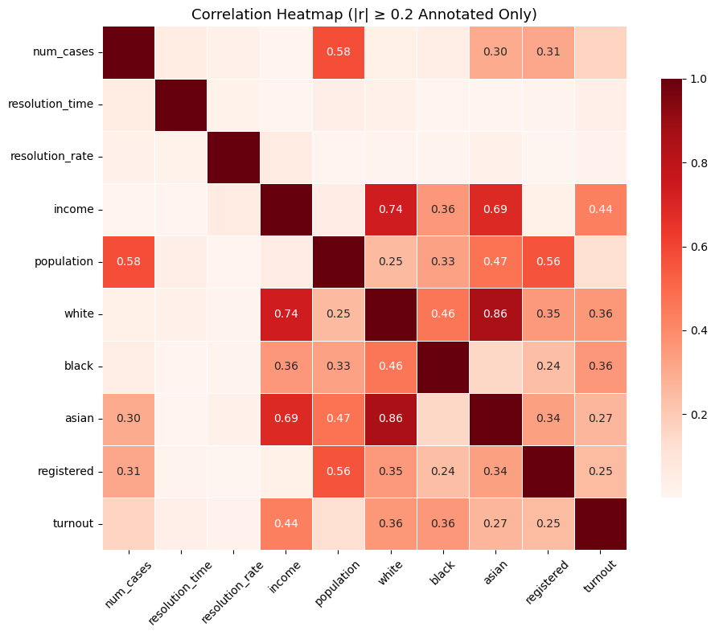

## Glimpses into 311-Reported Issues

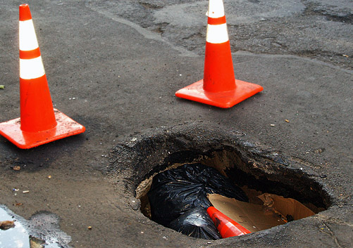

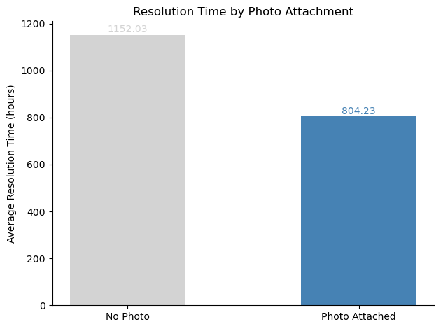

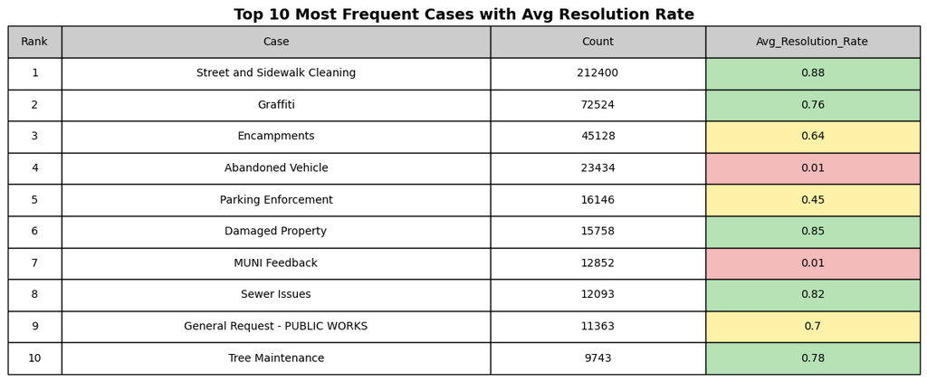

## Why It Matters

The 311 system is designed for accessibility and equity. But our analysis reveals:

These gaps — while subtle — matter. Because a small delay for one neighborhood might mean chronic neglect for another.

[figure not shown]

## Who This Is For

This dashboard is built for:

**Note**

- **Residents** who want to know how their neighborhood compares
- **City officials** seeking fairer resource allocation
- **Civic tech advocates** promoting transparency
- **Researchers and data scientists** interested in applied policy analysis

Whether you’re a policy student, data enthusiast, or simply a curious citizen — we invite you to explore.

## Full Research Paper

Want to dive deeper into the modeling details, statistical tests, and regression coefficients?

Download the full paper (PDF)

> “Data doesn’t change the world. Stories do — especially when the data is honest, and the stories are true.”

Let us know if you’d like to reuse this work or bring it to your city.  
The code is modular, the questions are transferable — and the insights can empower communities far beyond San Francisco.

Back to top